# A Decision Tool for Reducing Blood Tests in Hospitalised Patients

The following is a Random Forest model that aims to predict the next day's white blood cell counts (WCC) for a patient in hospital using the patients most up-to-date WCC results (regression) as well as determining whether those results will be within normal range and whether another blood test is recommended (classification).

See [here](https://www.youtube.com/watch?v=ide_M9U5ORU) for a (8-minute) presentation on the context of the problem, an overview of the solution, and the intended future development and deployment.

This model was created as part of the [2022 IntelliHQ x ANZICS Healthcare Datathon in Australia](https://www.intellihq.com.au/datathon-2022-event-page/) and got the [1<sup>st</sup> place at the regional level (Victoria)](https://www.linkedin.com/feed/update/urn:li:activity:6987647452031967232/) and the [2<sup>nd</sup> place at the national level](https://www.linkedin.com/feed/update/urn:li:activity:6988818471786610688/). This is a collaborative work between:

- [Jack Adderley (Data Scientist/Researcher)](https://www.linkedin.com/in/jack-adderley-phd/),
- [Patrick Burnett-Downie (Data Scientist)](https://www.linkedin.com/in/patrick-burnett-downie-814613171/),
- [Ben Gelbart (Intensivist/PhD candidate)](https://www.linkedin.com/in/ben-gelbart-6a642a69/),
- [Alexandra Karamesinis (Junior Doctor)](https://www.linkedin.com/in/alexandra-karamesinis/),
- [Finn O'Donoghue (Data Scientist/Researcher)](https://www.linkedin.com/in/finnod/), and
- [Sebastian Quezada Rojas (Data Scientist/Researcher)](https://www.linkedin.com/in/sebastian-quezada-rojas/).

*Important: The following is a work in progress and does not constitute the finalised tool. The code is presented as it was developed from inception (October 15th, 2022) and until the day of the national finals (October 20th, 2022). If you're interested in this problem and prototype, feel free to reach out!*

## Importing libraries and utilities

```python
import sys
import os
sys.path.append("../")
os.environ['AWS_STS_REGIONAL_ENDPOINTS']='regional'

import pandas as pd
import seaborn as sns
import matplotlib.pyplot as plt
import numpy as np

from utils.glue import Catalogue
from datetime import timedelta
from datetime import datetime
from utils.athena_query import Athena_Query
```

```python
catalogue = Catalogue()
catalogue.database_names
```

```
['mimic_iv']
```

## Connect with the relevant database and import the data

```python
database_name = catalogue.database_names[0]
database = catalogue.database(database_name)
```

```python
table_name = database.table_names[10]
table = database.table(table_name)
```

```python
athena = Athena_Query()
```

```python
table_name = 'labevents'

athena1 = Athena_Query(database='mimic_iv')
athena1.database = 'mimic_iv'

#itemid 51301 is the main test for WCC
labevents = athena1.query_as_pandas(f"SELECT * FROM {table_name} WHERE itemid IN (51301);")
```

```python
#Extract age
age = athena1.query_as_pandas(f"SELECT subject_id, anchor_age FROM {'patients'}")
#Extract albumin infusion (to be converted to binary any administration in last 24 hours)
alb_products = athena1.query_as_pandas(f"SELECT stay_id, starttime FROM {'inputevents'} WHERE itemid IN (220862, 220861, 220863, 220864) and amount is not null;")
```

```
.........
```

```python
#Import patient identifiers
icustays = athena.query_as_pandas(f"SELECT * FROM {database_name}.icustays;")
icustays.head()
```

```
...
```

|  | subject_id | hadm_id | stay_id | first_careunit | last_careunit | intime | outtime | los |
| --- | --- | --- | --- | --- | --- | --- | --- | --- |
| 0 | 17233909 | 24700140 | 37084004 | Trauma SICU (TSICU) | Trauma SICU (TSICU) | 2157-10-31 01:12:51 | 2157-11-02 15:48:08 | 2.607836 |
| 1 | 19185346 | 22127136 | 37084815 | Cardiac Vascular Intensive Care Unit (CVICU) | Cardiac Vascular Intensive Care Unit (CVICU) | 2110-04-07 10:56:47 | 2110-04-08 13:39:36 | 1.113067 |
| 2 | 13498867 | 24046990 | 37084966 | Coronary Care Unit (CCU) | Trauma SICU (TSICU) | 2151-07-16 13:40:11 | 2151-07-20 22:53:29 | 4.384236 |
| 3 | 17030600 | 25070620 | 37085562 | Surgical Intensive Care Unit (SICU) | Surgical Intensive Care Unit (SICU) | 2110-11-19 06:24:00 | 2110-11-20 17:16:26 | 1.453079 |
| 4 | 12408912 | 27098428 | 37086015 | Medical Intensive Care Unit (MICU) | Medical Intensive Care Unit (MICU) | 2146-02-22 22:19:51 | 2146-02-23 14:56:08 | 0.691863 |

## Data preprocessing

```python
alb_products['starttime'] = pd.to_datetime(alb_products['starttime'])
```

```python
labevents[['charttime','storetime']] = labevents[['charttime','storetime']].apply(pd.to_datetime)
```

```python
icustays[['intime','outtime']] = icustays[['intime','outtime']].apply(pd.to_datetime)
```

```python
merged = labevents.merge(icustays, on=['subject_id','hadm_id'], how='right')
```

```python
icubloods = merged[(merged['intime'] <= merged['charttime']) & (merged['charttime'] <= merged['outtime'])]
```

```python
icubloods['time_since_icu'] = icubloods['charttime'] - icubloods['intime']
```

```python
icubloods.reset_index(inplace=True, drop=True)
```

```python
icubloods.head(4)
```

|  | labevent_id | subject_id | hadm_id | specimen_id | itemid | charttime | storetime | value | valuenum | valueuom | ... | flag | priority | comments | stay_id | first_careunit | last_careunit | intime | outtime | los | time_since_icu |
| --- | --- | --- | --- | --- | --- | --- | --- | --- | --- | --- | --- | --- | --- | --- | --- | --- | --- | --- | --- | --- | --- |
| 0 | 89730556.0 | 17233909 | 24700140.0 | 53888401.0 | 51301.0 | 2157-10-31 03:12:00 | 2157-10-31 03:35:00 | 4.3 | 4.3 | K/uL | ... | NaN | STAT | NaN | 37084004 | Trauma SICU (TSICU) | Trauma SICU (TSICU) | 2157-10-31 01:12:51 | 2157-11-02 15:48:08 | 2.607836 | 0 days 01:59:09 |
| 1 | 89730575.0 | 17233909 | 24700140.0 | 2987617.0 | 51301.0 | 2157-11-01 03:55:00 | 2157-11-01 04:28:00 | 4.5 | 4.5 | K/uL | ... | NaN | ROUTINE | NaN | 37084004 | Trauma SICU (TSICU) | Trauma SICU (TSICU) | 2157-10-31 01:12:51 | 2157-11-02 15:48:08 | 2.607836 | 1 days 02:42:09 |
| 2 | 89730628.0 | 17233909 | 24700140.0 | 73099342.0 | 51301.0 | 2157-11-02 03:51:00 | 2157-11-02 05:01:00 | 10.8 | 10.8 | K/uL | ... | abnormal | STAT | NaN | 37084004 | Trauma SICU (TSICU) | Trauma SICU (TSICU) | 2157-10-31 01:12:51 | 2157-11-02 15:48:08 | 2.607836 | 2 days 02:38:09 |
| 3 | 113963710.0 | 19185346 | 22127136.0 | 35549681.0 | 51301.0 | 2110-04-07 11:35:00 | 2110-04-07 11:46:00 | 18.7 | 18.7 | K/uL | ... | abnormal | STAT | NaN | 37084815 | Cardiac Vascular Intensive Care Unit (CVICU) | Cardiac Vascular Intensive Care Unit (CVICU) | 2110-04-07 10:56:47 | 2110-04-08 13:39:36 | 1.113067 | 0 days 00:38:13 |

4 rows × 22 columns

```python
#Determining time from first test
ftt = icubloods.merge(icubloods.groupby(['hadm_id','stay_id','itemid'])['charttime'].min().rename('first_test_time'), on=['hadm_id','stay_id','itemid'], how='outer')['first_test_time']
icubloods['time_since_first_test'] = icubloods['charttime'] - ftt
```

```python
icubloods.head()
```

|  | labevent_id | subject_id | hadm_id | specimen_id | itemid | charttime | storetime | value | valuenum | valueuom | ... | priority | comments | stay_id | first_careunit | last_careunit | intime | outtime | los | time_since_icu | time_since_first_test |
| --- | --- | --- | --- | --- | --- | --- | --- | --- | --- | --- | --- | --- | --- | --- | --- | --- | --- | --- | --- | --- | --- |
| 0 | 89730556.0 | 17233909 | 24700140.0 | 53888401.0 | 51301.0 | 2157-10-31 03:12:00 | 2157-10-31 03:35:00 | 4.3 | 4.3 | K/uL | ... | STAT | NaN | 37084004 | Trauma SICU (TSICU) | Trauma SICU (TSICU) | 2157-10-31 01:12:51 | 2157-11-02 15:48:08 | 2.607836 | 0 days 01:59:09 | 0 days 00:00:00 |
| 1 | 89730575.0 | 17233909 | 24700140.0 | 2987617.0 | 51301.0 | 2157-11-01 03:55:00 | 2157-11-01 04:28:00 | 4.5 | 4.5 | K/uL | ... | ROUTINE | NaN | 37084004 | Trauma SICU (TSICU) | Trauma SICU (TSICU) | 2157-10-31 01:12:51 | 2157-11-02 15:48:08 | 2.607836 | 1 days 02:42:09 | 1 days 00:43:00 |
| 2 | 89730628.0 | 17233909 | 24700140.0 | 73099342.0 | 51301.0 | 2157-11-02 03:51:00 | 2157-11-02 05:01:00 | 10.8 | 10.8 | K/uL | ... | STAT | NaN | 37084004 | Trauma SICU (TSICU) | Trauma SICU (TSICU) | 2157-10-31 01:12:51 | 2157-11-02 15:48:08 | 2.607836 | 2 days 02:38:09 | 2 days 00:39:00 |
| 3 | 113963710.0 | 19185346 | 22127136.0 | 35549681.0 | 51301.0 | 2110-04-07 11:35:00 | 2110-04-07 11:46:00 | 18.7 | 18.7 | K/uL | ... | STAT | NaN | 37084815 | Cardiac Vascular Intensive Care Unit (CVICU) | Cardiac Vascular Intensive Care Unit (CVICU) | 2110-04-07 10:56:47 | 2110-04-08 13:39:36 | 1.113067 | 0 days 00:38:13 | 0 days 00:00:00 |
| 4 | 113963737.0 | 19185346 | 22127136.0 | 21501963.0 | 51301.0 | 2110-04-07 12:17:00 | 2110-04-07 13:29:00 | 23.3 | 23.3 | K/uL | ... | STAT | NaN | 37084815 | Cardiac Vascular Intensive Care Unit (CVICU) | Cardiac Vascular Intensive Care Unit (CVICU) | 2110-04-07 10:56:47 | 2110-04-08 13:39:36 | 1.113067 | 0 days 01:20:13 | 0 days 00:42:00 |

5 rows × 23 columns

```python
# Perform resampling to create time series of WCC from patient data and forward-fill missing values
resamplingHours = 2
icuresampled = icubloods.head(10000).groupby(['hadm_id','stay_id','itemid']).resample(timedelta(hours=resamplingHours), on = 'time_since_first_test').last().ffill()
icuresampled.drop(columns=['time_since_first_test'], inplace=True)
```

```python
icuresampled.drop(columns = ['hadm_id','stay_id', 'itemid'], inplace = True, errors='ignore')
```

```python
icuresampled2 = icuresampled.reset_index(level=[3])
```

```python
icuresampled2['hours_since_first_test'] = icuresampled2.apply(lambda x: x['time_since_first_test']/pd.Timedelta(hours=1), axis=1)
```

```python
#Subset the data to patients with ICU stay longer than 1 day
fish = pd.DataFrame(icuresampled2.groupby(['hadm_id','stay_id', 'itemid'])['time_since_icu'].max() > timedelta(days=1))
fish.rename(columns = {'time_since_icu':'long_stay'},inplace = True)
```

```python
fish = fish.merge(icuresampled2, how ='left', on = ['hadm_id','stay_id', 'itemid'])
```

```python
longfish = fish[fish.long_stay]
```

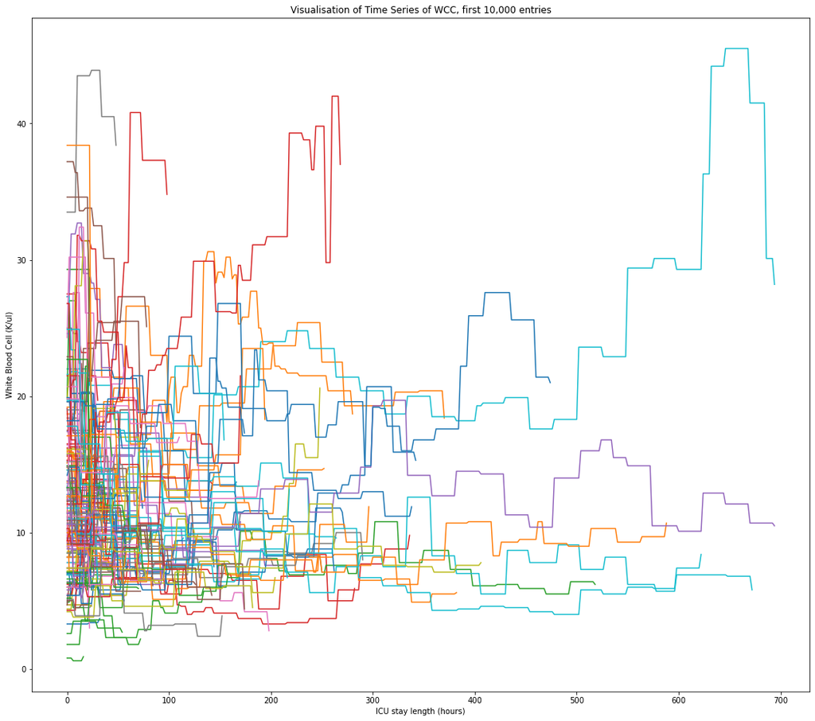

```python
#Visualise the first 10,000 entries for the time series, each line is a patient
fig, (ax1) = plt.subplots(1, 1, figsize=(18,16))
sns.lineplot(data = longfish.head(10000), x = 'hours_since_first_test', y='value', hue='stay_id', palette="tab10", ax=ax1)
ax1.legend([],[], frameon=False)
ax1.set(
        xlabel ='ICU stay length (hours)',
        ylabel = 'White Blood Cell (K/ul)',
        title = 'Visualisation of Time Series of WCC, first 10,000 entries'
        );
```

```python
#Add lagged values to create serial dependence
for i in range(6,42): # 84 - 12h prior
    longfish[f'value_lag{i+1}'] = longfish.groupby(['itemid', 'stay_id', 'hadm_id'], observed=True)['valuenum'].shift(i+1)
```

```python
longfish.reset_index(level=[1], inplace=True)
```

## Prepare the data to train the model

```python
pre_X = longfish.drop(columns =['long_stay',
 'time_since_first_test','labevent_id','specimen_id','storetime','valuenum','valueuom','ref_range_lower','ref_range_upper','flag',
 'priority','comments','first_careunit','last_careunit','outtime','los','time_since_icu','hours_since_first_test'])
```

```python
pre_X = pre_X.merge(age, how = 'left', on ='subject_id')
```

```python
pre_X = pre_X.drop(columns =['subject_id', 'charttime'])
```

```python
pre_X = pre_X.merge(alb_products, on = 'stay_id', how= 'left')
```

```python
pre_X['alb'] = pre_X['starttime'] - pre_X['intime'] < timedelta(days=1)
```

```python
pre_X = pre_X.drop(columns =['intime', 'starttime'], errors='ignore')
```

```python
pre_X.fillna(value=-1, inplace = True)
pre_X.head()
```

|  | stay_id | value | value_lag7 | value_lag8 | value_lag9 | value_lag10 | value_lag11 | value_lag12 | value_lag13 | value_lag14 | ... | value_lag35 | value_lag36 | value_lag37 | value_lag38 | value_lag39 | value_lag40 | value_lag41 | value_lag42 | anchor_age | alb |
| --- | --- | --- | --- | --- | --- | --- | --- | --- | --- | --- | --- | --- | --- | --- | --- | --- | --- | --- | --- | --- | --- |
| 0 | 38291712 | 9.5 | -1.0 | -1.0 | -1.0 | -1.0 | -1.0 | -1.0 | -1.0 | -1.0 | ... | -1.0 | -1.0 | -1.0 | -1.0 | -1.0 | -1.0 | -1.0 | -1.0 | 67 | False |
| 1 | 38291712 | 9.5 | -1.0 | -1.0 | -1.0 | -1.0 | -1.0 | -1.0 | -1.0 | -1.0 | ... | -1.0 | -1.0 | -1.0 | -1.0 | -1.0 | -1.0 | -1.0 | -1.0 | 67 | False |
| 2 | 38291712 | 9.5 | -1.0 | -1.0 | -1.0 | -1.0 | -1.0 | -1.0 | -1.0 | -1.0 | ... | -1.0 | -1.0 | -1.0 | -1.0 | -1.0 | -1.0 | -1.0 | -1.0 | 67 | False |
| 3 | 38291712 | 7.7 | -1.0 | -1.0 | -1.0 | -1.0 | -1.0 | -1.0 | -1.0 | -1.0 | ... | -1.0 | -1.0 | -1.0 | -1.0 | -1.0 | -1.0 | -1.0 | -1.0 | 67 | False |
| 4 | 38291712 | 7.7 | -1.0 | -1.0 | -1.0 | -1.0 | -1.0 | -1.0 | -1.0 | -1.0 | ... | -1.0 | -1.0 | -1.0 | -1.0 | -1.0 | -1.0 | -1.0 | -1.0 | 67 | False |

5 rows × 40 columns

## Train the model

```python
#Remove unrequired columns from training cols
X = pre_X.drop(columns = ['value', 'stay_id'])
y = pre_X['value']
```

```python
from sklearn.ensemble import RandomForestRegressor
from sklearn.ensemble import RandomForestClassifier
from sklearn.datasets import make_classification
from sklearn.metrics import r2_score, mean_squared_error, mean_absolute_error, plot_roc_curve
from sklearn.model_selection import train_test_split
import time
```

```python
X_train, X_test, y_train, y_test = train_test_split(X, y, test_size=0.3, random_state=123)
```

```python
clf = RandomForestRegressor(n_estimators=200, max_depth=5, random_state=0)
start = time.time()
clf.fit(X_train, y_train)
print(time.time()-start)
```

```
138.63172268867493
```

```python
y_pred = clf.predict(X_test)
r2 = r2_score(y_test, y_pred)
mse = mean_squared_error(y_test, y_pred)
mae = mean_absolute_error(y_test, y_pred)
```

```python
#print out metrics
print("r2: ", r2, '\n'
      "mse: ", mse, '\n'
      "mae: ", mae)
```

```
r2:  0.8640473234871016
mse:  14.30193593398133
mae:  2.0901265023908504
```

```python
# Fit a classifer
y_train_clas = (y_train <= 11.0) & (y_train >= 2.0)
y_train_clas = [int(x) for x in y_train_clas]

y_test_clas = (y_test <= 11.0) & (y_test >= 2.0)
y_test_clas = [int(x) for x in y_test_clas]

clf_2 = RandomForestClassifier(n_estimators = 200, max_depth = 5, random_state=0)
start = time.time()
clf_2.fit(X_train, y_train_clas)
print(time.time()-start)
```

```
27.226195335388184
```

```python
y_pred_clas = clf_2.predict(X_test)
y_pred_clas[13:25]
```

```
array([1, 0, 0, 0, 0, 0, 1, 0, 0, 0, 0, 0])
```

## Evaluate the model

```python
from sklearn.metrics import confusion_matrix

matrix = confusion_matrix(y_test_clas, y_pred_clas)
print(matrix)
```

```
[[28038  4597]
 [ 2839 31553]]
```

```python
round((matrix[1][0]/(len(y_test_clas)))*100,2)
```

```
4.24
```

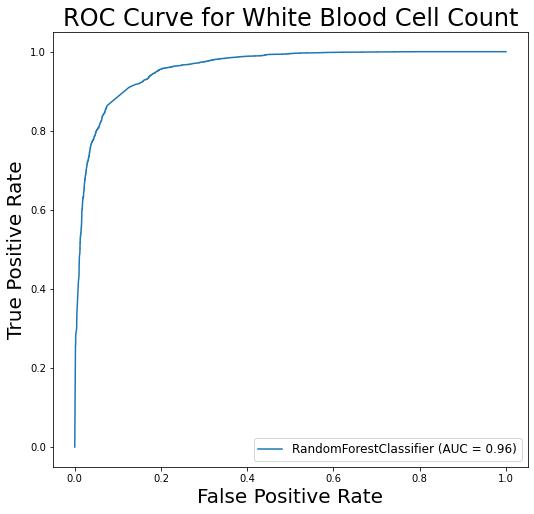

```python
# Greate a ROC curve (required trained classifier)
fig, ax = plt.subplots(1,1, figsize=(8.5,8))
roc_curve = plot_roc_curve(clf_2, X_test, y_test_clas, ax = ax)
ax.set_title('ROC Curve for White Blood Cell Count', fontsize = 24)
ax.set_xlabel('False Positive Rate', fontsize = 20)
ax.set_ylabel('True Positive Rate', fontsize = 20)
ax.legend(fontsize = 12)
plt.show()
```

```python
# Combine regressor and classifier
pred_level = clf.predict(X_test)
pred_norm  = clf_2.predict(X_test)
norm_proba = clf_2.predict_proba(X_test)
```

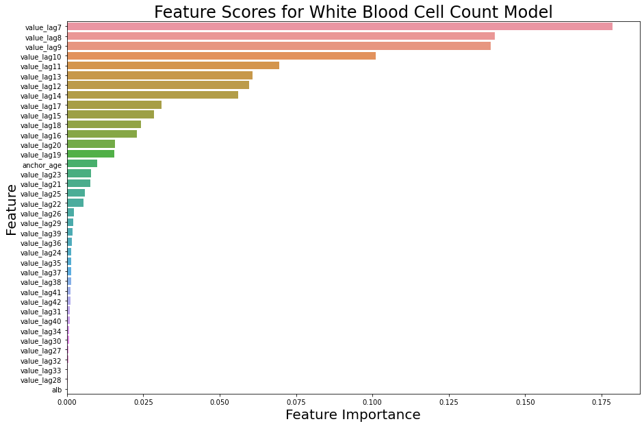

```python
# Global feature importance for ALL training data
feature_scores = pd.Series(clf_2.feature_importances_, index=X_train.columns).sort_values(ascending=False)
f, ax = plt.subplots(figsize=(15, 10))
ax = sns.barplot(x=feature_scores, y=feature_scores.index)
ax.set_yticklabels(feature_scores.index)
ax.set_title('Feature Scores for White Blood Cell Count Model', fontsize = 24)
ax.set_xlabel('Feature Importance', fontsize = 20)
ax.set_ylabel('Feature', fontsize = 20)
plt.show()
```

```python
# Example output
WBC_preds = pd.DataFrame({'pred_level':pred_level, 'pred_norm':pred_norm, 'confid_percent':np.amax(norm_proba, axis=1)*100})
WBC_preds = WBC_preds.replace(0, 'BLOODS REQUIRED').replace(1, 'BLOODS NOT REQUIRED')
WBC_preds.iloc[13:25]
```

|  | pred_level | pred_norm | confid_percent |
| --- | --- | --- | --- |
| 13 | 8.134128 | BLOODS NOT REQUIRED | 95.693072 |
| 14 | 17.009877 | BLOODS REQUIRED | 98.627366 |
| 15 | 11.962857 | BLOODS REQUIRED | 72.852535 |
| 16 | 14.409101 | BLOODS REQUIRED | 81.519891 |
| 17 | 11.724305 | BLOODS REQUIRED | 51.125276 |
| 18 | 18.943167 | BLOODS REQUIRED | 98.242839 |
| 19 | 8.134128 | BLOODS NOT REQUIRED | 95.693072 |
| 20 | 13.057116 | BLOODS REQUIRED | 59.561591 |
| 21 | 15.293528 | BLOODS REQUIRED | 89.281453 |
| 22 | 22.503490 | BLOODS REQUIRED | 98.373760 |
| 23 | 15.374689 | BLOODS REQUIRED | 95.133055 |
| 24 | 17.009877 | BLOODS REQUIRED | 81.558589 |